# Design & Analysis workshop

Priscila López-Beltrán Forcada

Spring 2021

In this session, we will learn the basics of **Multilevel modeling.**

The first crucial concept to understand is that these models are used when we have *hierarchical*, also called *nested*, data. These data have *levels*, hence *multilevel*, that group the data together. See the example below:

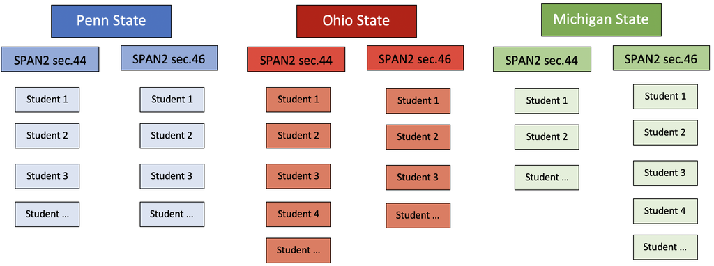

Multilevel models have a series of benefits that make them superior to other methods when handling data:

**1. Homogeneity of slopes:** unlike linear regression or ANOVA, multilevel models are especially designed to model variability in regression slopes.

**2. Assumption of independence:** multilevel models deal with nested data and, as such, do not assume that datapoints are necessarily independent of each other. In fact, they are designed to model this dependency.

**3. Missing data:** they can handle missing data really well, unlike regression or ANOVA.

#### Fixed vs. Random

**1. Coefficients: Intercepts and Slopes**

- *Random intercepts:* relationship between x-y (predictor-outcome) is the same, just located at different geometric space. Models the variance between subjects and between items in the mean of the dependent variable.
- *Random slopes:* relationship between x-y is different but located at the same geometric space. Models the variance between subjects and between items for all main effects and interactions.
- *Random intercepts and slopes:* the relationship between x-y varies by shape and location (mot realistic)

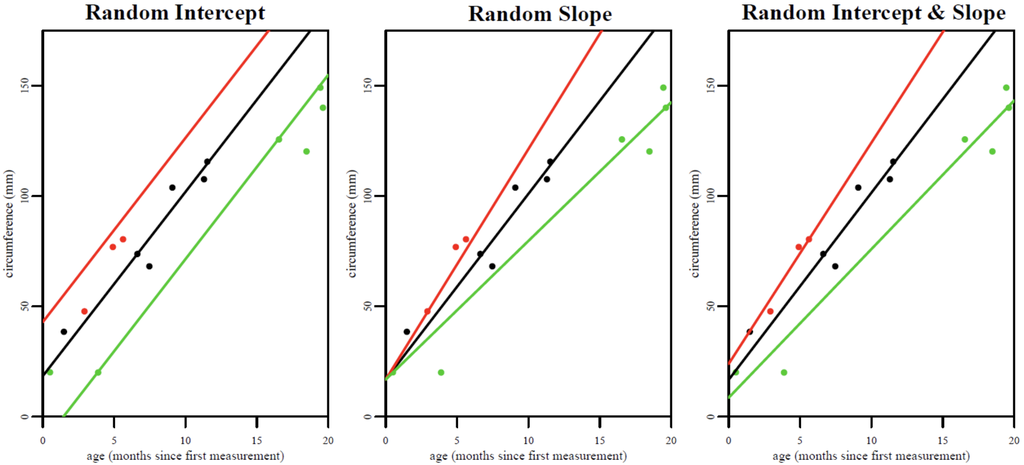

**2. Variables**

This distinction will be crucial when considering which variables we can include in our random effects structure.

- Fixed variables are those which do not change over time, for example a person’s gender.
- Random variables are those which change over time, for example a person’s weight or age

**3. Effects**

The analysis of the data is different, depending on whether the factor is treated as fixed or as random. Consequently, inferences may be incorrect if the factor is classified inappropriately.

- Fixed effects most commonly represent the experimental manipulation designed by the researcher. we are *only* interested in the levels of our manipulation (i.e., conditions),
- Random effects are those of which the experiment contains only a random sample of possible treatment conditions. The factor has many possible levels, interest is in all possible levels, but only a random sample of levels is included in the data. For example a random sample of participants and items; the analysis will not estimate the effect of each of the participants in the sample, but will instead estimate the variability attributable to the factor “participant”.

Models tha include both fixed and random effects are called *mixed effects models.*

*CRUCIALLY: WE GENERALIZE THE RESULTS OF FIXED EFFECTS ONTO OUR RANDOM EFFECTS AND, THERFORE, THE GENERAL POPULATION.*

*EXAMPLE:* We generalize the results of a reading experiment with actives/passives (CONDITIONS = FIXED) onto monolingual and bilingual speakers (PARTICIPANTS = RANDOM). Our study is made stronger by being able to generalize to a larger population by means of our random effects, than just being able to make an assertion about a particular group of participants if we only had fixed effects.

#### Covariance Structures

If were have any random effects or repeated measures in y=our multilevel model, then we have to decide upon the *covariance structure* of our data. The covariance structure is important because R uses it as a starting point to estimate the model parameters.

First, we will create a model *with random intercepts only*. The notation *(1 | x)* indicates that this is a random effect, 1| denotes it’s a random intercept, and x refers to the grouping variable.

**CAREFUL:** when we specify a covariance structure that is too simple, then we are more likely to make a Type I error (a.k.a. false positive).

```r
model0 <- lmer(total ~ congruency*voice # fixed effects
                                  + (1 | participant) # random intercept by participant
                                  + (1 |item) # random intercept by item
                                  , data = monolingual_data_clean
                                  , REML = FALSE
                                  , control = lmerControl(optimizer = "bobyqa"))
summary(model0)
```

```
## Linear mixed model fit by maximum likelihood . t-tests use Satterthwaite's
##   method [lmerModLmerTest]
## Formula: total ~ congruency * voice + (1 | participant) + (1 | item)
##    Data: monolingual_data_clean
## Control: lmerControl(optimizer = "bobyqa")
##
##      AIC      BIC   logLik deviance df.resid
##  23873.2  23910.9 -11929.6  23859.2     1609
##
## Scaled residuals:
##     Min      1Q  Median      3Q     Max
## -3.3327 -0.5916 -0.1444  0.4431  5.1715
##
## Random effects:
##  Groups      Name        Variance Std.Dev.
##  item        (Intercept)  15411   124.1
##  participant (Intercept)  52025   228.1
##  Residual                134917   367.3
## Number of obs: 1616, groups:  item, 80; participant, 30
##
## Fixed effects:
##                                    Estimate Std. Error      df t value Pr(>|t|)
## (Intercept)                          804.73      47.88   42.04  16.808  < 2e-16
## congruencyIncongruent                 47.80      26.06 1534.42   1.834   0.0668
## voicePassive                         114.78      25.83 1533.54   4.444 9.46e-06
## congruencyIncongruent:voicePassive    88.16      37.17 1539.39   2.372   0.0178
##
## (Intercept)                        ***
## congruencyIncongruent              .
## voicePassive                       ***
## congruencyIncongruent:voicePassive *
## ---
## Signif. codes:  0 '***' 0.001 '**' 0.01 '*' 0.05 '.' 0.1 ' ' 1
##
## Correlation of Fixed Effects:
##             (Intr) cngrnI vcPssv
## cngrncyIncn -0.266
## voicePassiv -0.266  0.487
## cngrncyIn:P  0.185 -0.701 -0.695
```

**Note:** we would normally run this model using log-tranformed RTs and centered factors, however, I am not doing so for the sake of clarity.

Let’s dissect this massive output:

#### **1. Goodness-of-fit**

We first have a series of measures of goodness-of-fit such as AIC and BIC. By themselves, these figures don’t tell us much, but when we start building more complex models, we need to pay attention to them to see if they go down: smaller AIC values will indicate that the more complex model is accounting for more variance in the data.

#### **2. Scaled residuals**

If we plot the scaled residuals for the model, we can see the fit is good. For a correctly specified model we would expect a uniform (flat) distribution of the scaled residuals.

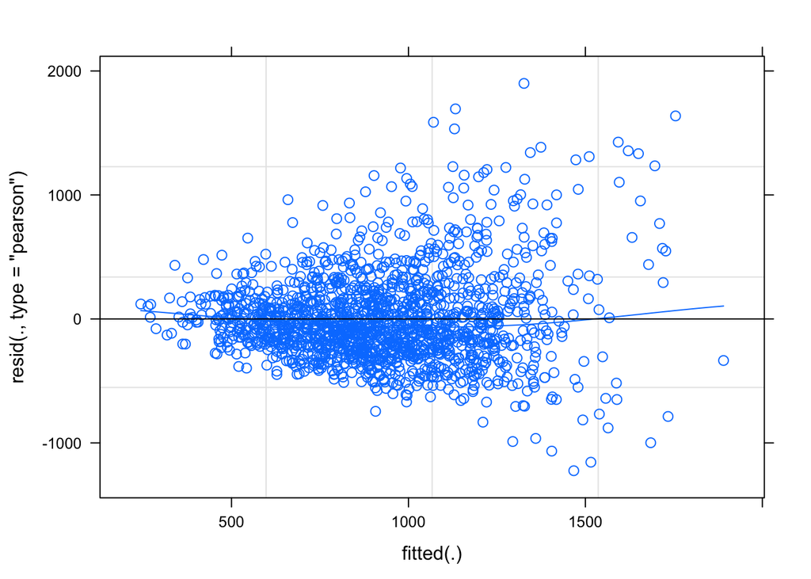

```r
plot(model0,type=c("p","smooth"))
```

#### **3. Random effects**

This part of the model output is often neglected, even though it can give us important information about our model!

The standard deviation of random effects can tell us how much intercepts varied over our level 1 variable, that is, participant and item. In this particular case, we see the standard deviations are not huge which, in turn, entails there weren’t huge differences in RTs during reading for our participant sample. This also means that we controlled for our items properly, as there weren’t huge differences in the reading of different sentences.

#### **4. Fixed Effects**

Like liner regression, we have the Estimates, the Standard error, the t-value and p-value. Here, we also have degrees of freedom, which indicates the number values that have the freedom to vary in the data sample.

The fixed effects indicate that:

- There is a marginally significantly positive main effect of information structure. When IS is New-Given (Incongruent), RTs go up 47.80 ms. The reason why this main effect is probably not so significant is that it’s being soaked up y the interaction.
- There is a significantly positive main effect of voice. When voice is Passive, RTs go up 114.78 ms
- There is a significantly positive interaction between information structure and voice. When the item is New-Given *and* Passive, RTs go up 88.16 ms.

Now, we will create a model that also contains *random slopes*. The notation *(1 + x | x)* indicates that this is a random effect, 1+ denotes it’s a random slope and x specifies the random variables, while | denotes there is also a random intercept and and x refers to the grouping variable.

```r
model1 <- lmer(total ~ congruency*voice # fixed effects
                                  + (1 + congruency+voice | participant) # random intercept & slope by participant
                                  + (1 + congruency+voice |item) # random intercept & slope by item
                                  , data = monolingual_data_clean
                                  , REML = FALSE
                                  , control = lmerControl(optimizer = "bobyqa"))
```

```
## boundary (singular) fit: see ?isSingular
```

```r
summary(model1)
```

```
## Linear mixed model fit by maximum likelihood . t-tests use Satterthwaite's
##   method [lmerModLmerTest]
## Formula: total ~ congruency * voice + (1 + congruency + voice | participant) +
##     (1 + congruency + voice | item)
##    Data: monolingual_data_clean
## Control: lmerControl(optimizer = "bobyqa")
##
##      AIC      BIC   logLik deviance df.resid
##  23882.4  23974.0 -11924.2  23848.4     1599
##
## Scaled residuals:
##     Min      1Q  Median      3Q     Max
## -3.3999 -0.6053 -0.1414  0.4332  4.9985
##
## Random effects:
##  Groups      Name                  Variance Std.Dev. Corr
##  item        (Intercept)            12012.2 109.60
##              congruencyIncongruent    414.5  20.36   1.00
##              voicePassive             155.2  12.46   1.00 1.00
##  participant (Intercept)            35381.9 188.10
##              congruencyIncongruent   1929.1  43.92   0.88
##              voicePassive            3507.7  59.23   0.64 0.93
##  Residual                          133367.7 365.20
## Number of obs: 1616, groups:  item, 80; participant, 30
##
## Fixed effects:
##                                    Estimate Std. Error      df t value Pr(>|t|)
## (Intercept)                          808.64      40.95   36.83  19.746  < 2e-16
## congruencyIncongruent                 44.95      27.21  215.32   1.652 0.099986
## voicePassive                         112.12      27.94   78.25   4.013 0.000136
## congruencyIncongruent:voicePassive    82.42      37.02 1529.37   2.226 0.026136
##
## (Intercept)                        ***
## congruencyIncongruent              .
## voicePassive                       ***
## congruencyIncongruent:voicePassive *
## ---
## Signif. codes:  0 '***' 0.001 '**' 0.01 '*' 0.05 '.' 0.1 ' ' 1
##
## Correlation of Fixed Effects:
##             (Intr) cngrnI vcPssv
## cngrncyIncn -0.045
## voicePassiv -0.056  0.536
## cngrncyIn:P  0.213 -0.666 -0.636
## optimizer (bobyqa) convergence code: 0 (OK)
## boundary (singular) fit: see ?isSingular
```

The results are largely similar to the ones of the previous model, however, we do see that the AIC value has gone up slightly, indicating that this second model’s fit is somewhat worse. If we compare both models, we see that model 1 does not improve over model 0. Thus, random intercepts are enough to account for the variance in this data set.

```r
anova(model0, model1)
```

```
## Data: monolingual_data_clean
## Models:
## model0: total ~ congruency * voice + (1 | participant) + (1 | item)
## model1: total ~ congruency * voice + (1 + congruency + voice | participant) +
## model1:     (1 + congruency + voice | item)
##        npar   AIC   BIC logLik deviance  Chisq Df Pr(>Chisq)
## model0    7 23873 23911 -11930    23859
## model1   17 23882 23974 -11924    23848 10.735 10     0.3785
```

Now, the models that we built here are somewhat simple, we don’t have a large number of variables or covariates. in other words, these models are *parsimonious*, they include just the right amount of variables. However, we could also create *maximal* models that include all possible variables we are interested in. Let’s look into these possibilities:

**1. Barr et al., (2013) Random effects structure for confirmatory hypothesis testing: Keep it maximal**

Key points:

- Using maximal random-effects structures in our models reduces the risk of Type I error.
- Maximal random-effects structures make findings more generalizable.

**2. Bates et al., (2015) Parsimonious Mixed Models**

Key points:

- Maximal models create worrying convergence issues.
- Maximal models can critically overfit the data.
- Iterative reduction (i.e., stepwise selection) to create parsimonious models is preferable.

Since the advent of the study by Bates et al., few researchers use the maximal approach given its many issues. In our case, if we wanted to create a larger model, we’d still need to compare it with simpler models to make sure that each variable that we include actually improves the model’s fit. This is were **stepwise regression** will help us.

Stepwise regression (or stepwise selection) consists of iteratively adding and removing predictors, in the model, in order to find the subset of variables in the data set resulting in the best performing model, that is a model that lowers prediction error.

There are three strategies in stepwise regression:

- **Forward selection**, which starts with no predictors in the model, iteratively adds the most contributive predictors, and stops when the improvement is no longer statistically significant.
- **Backward selection**, (or backward elimination), which starts with all predictors in the model (full model), iteratively removes the least contributive predictors, and stops when you have a model where all predictors are statistically significant.
- **Stepwise selection**, (or sequential replacement), which is a combination of forward and backward selections. You start with no predictors, then sequentially add the most contributive predictors (like forward selection). After adding each new variable, remove any variables that no longer provide an improvement in the model fit (like backward selection).

There are several ways in which stepwise selection can be performed, here we will talk about two:

**1. Manual selection:** we have actually already done this above; this method consists of manually adding or subtracting a variable and then comparing models to check if the AIC and BIC values have improved.

**2. Using th function `buildmer()`**

This function uses lmer from the `lme4` package but allows for a systematic and replicable way of simplifying random effects structures and testing fixed effects. The function starts by attempting to fit the most maximal model possible. If the model fails to converge, the function then simplifies the random effects structure via backwards stepwise elimination; in other words, it attempts to find the maximal random effects structure that still allows the model to converge. Once the maximally converging model has been identified, the function calculates p-values for all fixed effects based on Satterthwaite denominator degrees of freedom using the `lmerTest` package. The resulting models were the maximally converging models that the data were able to support.

First, let’s create a more “maximal” model

```r
model_max <- buildmer(total ~ congruency*voice + PN_RT + PN_ACC + VF + MELICET
                                  + (1 + congruency + voice+ PN_RT + PN_ACC + VF + MELICET | participant)
                                  + (1 + congruency + voice + PN_RT + PN_ACC + VF + MELICET |item)
                                  , data = monolingual_data_clean
                                  , REML = TRUE
                                  , control = lmerControl(optimizer = "bobyqa"))
```

```
##        grouping             term                  block       score Iteration
## 1          <NA>                1                NA NA 1          NA         1
## 7          <NA>            voice            NA NA voice  -31.376239         1
## 6          <NA>               VF               NA NA VF  -11.793373         1
## 5          <NA>            PN_RT            NA NA PN_RT  -21.032557         1
## 4          <NA>           PN_ACC           NA NA PN_ACC  -15.942532         1
## 11         <NA>       congruency       NA NA congruency  -12.128096         1
## 2          <NA>          MELICET          NA NA MELICET   -1.528184         1
## 12         <NA> congruency:voice NA NA congruency:voice   -5.806812         1
## 8   participant                1       NA participant 1 -170.890460         1
## 13         item                1              NA item 1  -41.632775         1
## 121 participant            voice   NA participant voice   -4.277960         1
##              LRT
## 1             NA
## 7             NA
## 6   4.735985e-03
## 5   7.742120e-03
## 4   1.037145e-03
## 11            NA
## 2   5.034248e-03
## 12  6.741563e-05
## 8             NA
## 13  9.392556e-18
## 121 1.387093e-02
```

```r
summary(model_max)
```

```
## Linear mixed model fit by REML
## (p-values based on Wald z-scores) ['lmerMod']
## Formula: total ~ 1 + voice + VF + PN_RT + PN_ACC + congruency + MELICET +
##     voice:congruency + (1 + voice | participant) + (1 | item)
##    Data: monolingual_data_clean
## Control: lmerControl(optimizer = "bobyqa")
##
## REML criterion at convergence: 23792.6
##
## Scaled residuals:
##     Min      1Q  Median      3Q     Max
## -3.5143 -0.5996 -0.1370  0.4277  5.0578
##
## Random effects:
##  Groups      Name         Variance Std.Dev. Corr
##  item        (Intercept)   15422   124.19
##  participant (Intercept)   36710   191.60
##              voicePassive   3857    62.11   0.87
##  Residual                 134289   366.45
## Number of obs: 1616, groups:  item, 80; participant, 30
##
## Fixed effects:
##                                      Estimate Std. Error t value Pr(>|t|)
## (Intercept)                        -1347.6640   871.8672  -1.546   0.1222
## voicePassive                         111.0325    28.2218   3.934 8.34e-05 ***
## VF                                     6.2556     4.5987   1.360   0.1737
## PN_RT                                  1.0350     0.4021   2.574   0.0100 *
## PN_ACC                                19.3736    11.4933   1.686   0.0919 .
## congruencyIncongruent                 46.9725    25.9884   1.807   0.0707 .
## MELICET                               -4.7671     9.7828  -0.487   0.6260
## voicePassive:congruencyIncongruent    87.1295    37.0939   2.349   0.0188 *
## ---
## Signif. codes:  0 '***' 0.001 '**' 0.01 '*' 0.05 '.' 0.1 ' ' 1
##
## Correlation of Fixed Effects:
##             (Intr) vcPssv VF     PN_RT  PN_ACC cngrnI MELICE
## voicePassiv -0.003
## VF          -0.155 -0.001
## PN_RT       -0.620 -0.009 -0.023
## PN_ACC      -0.708  0.011 -0.270  0.354
## cngrncyIncn -0.019  0.443  0.005 -0.002  0.008
## MELICET     -0.285 -0.001  0.169 -0.049 -0.315 -0.005
## vcPssv:cngI  0.015 -0.634 -0.004  0.001 -0.008 -0.700  0.004
```

Let’s dissect this output;

#### Formula

Formula: total ~ 1 + voice + VF + PN_RT + PN_ACC + congruency + MELICET +  
voice:congruency + (1 + voice | participant) + (1 | item)

We see that the final formula selected by `buildmer()` includes all fixed effects but has only left a random slope for voice by participant and a random intercept by item. This entails that most of the variability in the model was captured by the factor voice.

#### Residuals

Residuals appear rather flat along 0, as we’d expect.

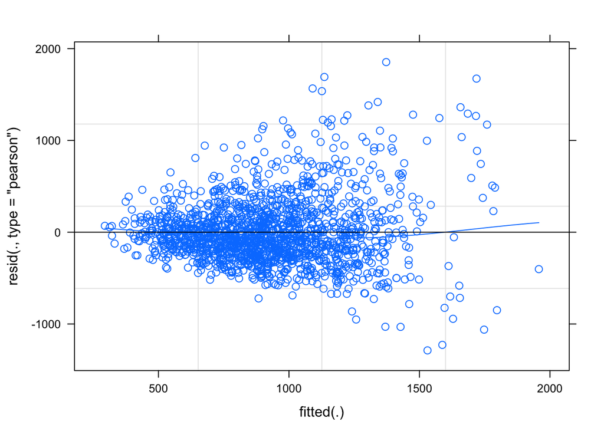

```r
plot(model_max,type=c("p","smooth"))
```

#### Random effects

The standard deviations are fairly similar to those of our smaller model; we see they are still higher for paricipant than for item, indicating there was more variation in the former.

#### Fixed effects

The coefficient show:

- A significant main effect of voice
- A significant main effect of picture naming RTs
- A marginally significant main effect of picture naming accuracy
- A marginally significant main effect of information structure
- A significant interaction between voice and information structure

#### Resources

- Readings
  - This corresponds to Andy Field’s book Chapter 19.
  - Magezi (2015) Linear mixed-effects models for within-participant psychology experiments
  - Austin et al., (2001) An Introduction to Multilevel Regression Models
  - Balling (2008) A brief introduction to regression designs and mixed-effects modeling by a recent convert
  - Cunnings (2012) An overview of mixed-effects statistical models for second language researchers
  - Barr et al., (2013) Random effects structure for confirmatory hypothesis testing: Keep it maximal
  - Bates et al., (2015) Parsimonious Mixed Models
  - Lever et al., (2015) Model selection and overfitting
- Mixed effects
  - http://www.rensenieuwenhuis.nl/r-sessions-16-multilevel-model-specification-lme4/
  - https://www.youtube.com/watch?v=1rTb72pCPT8&ab_channel=StatisticsofDOOM
  - https://rstudio-pubs-static.s3.amazonaws.com/78961_fe5b5c6a77f446eca899afbb32bd1dc7.html
- Fixed vs. Random
  - http://web.pdx.edu/~newsomj/mlrclass/ho_randfixd.pdf
  - https://web.ma.utexas.edu/users/mks/statmistakes/fixedvsrandom.html